# candy characteristics using regression

# Question of interest

The general goal is to find characteristics of popular candy brands and, subsequently, trying to come up with a business recommendation for a potential new candy. Here, I used a data resulting from an [online survey](http://walthickey.com/2017/10/18/whats-the-best-halloween-candy/) asking the following question: *“Please select which fun-size Halloween treat you would most want to receive as a trick-or-treater.”*

## history

Afterwards, the participant is asked to choose between two candies (randomly sampled from a total of 83 candies). By Oct. 27th, 2017, 8,371 different IP addresses voted on about 269,000 randomly generated matchups (i.e., on average, each participant voted for ~30 candies). Considering the amount of participants and number of votes it seems reasonable to assume that all candies were sufficiently matched-up against each other. Thus, the data set gives a good impression what candies are favored and which not. The outcome of the study provided the win rate [in percent] for each individual candy.

# Data import an quality assessment of data set

# data understanding

```r
# Loading required R libraries
library(tidyverse)
library(skimr)
library(Hmisc)
library(psych)
library(corrplot)
library(rpart)
library(rpart.plot)
library(lattice)
library(rmarkdown)
library(gridExtra)

# setting ggplot visualization theme
theme_set(theme_classic())

# file location
url="C:/Users/AZAN LAPTOP STORE/Downloads/archive/candy-data.csv"

# file import and class assignment of attributes
candy_raw <- read_csv(url, col_types = c("clllllllllddd"))

# replacing odd characters
candy_raw$competitorname <- candy_raw$competitorname %>% str_replace("Õ", "'")

# renaming attributes
candy_renamed <- candy_raw %>% rename(candy = competitorname,
                                      peanut_almond = peanutyalmondy,
                                      rice_wafer_cooky = crispedricewafer,
                                      multipiece = pluribus)
# data overview
glimpse(candy_renamed)
```

```
## Rows: 85
## Columns: 13
## $ candy            <chr> "100 Grand", "3 Musketeers", "One dime", "One quarter…
## $ chocolate        <lgl> TRUE, TRUE, FALSE, FALSE, FALSE, TRUE, TRUE, FALSE, F…
## $ fruity           <lgl> FALSE, FALSE, FALSE, FALSE, TRUE, FALSE, FALSE, FALSE…
## $ caramel          <lgl> TRUE, FALSE, FALSE, FALSE, FALSE, FALSE, TRUE, FALSE,…
## $ peanut_almond    <lgl> FALSE, FALSE, FALSE, FALSE, FALSE, TRUE, TRUE, TRUE, …
## $ nougat           <lgl> FALSE, TRUE, FALSE, FALSE, FALSE, FALSE, TRUE, FALSE,…
## $ rice_wafer_cooky <lgl> TRUE, FALSE, FALSE, FALSE, FALSE, FALSE, FALSE, FALSE…
## $ hard             <lgl> FALSE, FALSE, FALSE, FALSE, FALSE, FALSE, FALSE, FALS…
## $ bar              <lgl> TRUE, TRUE, FALSE, FALSE, FALSE, TRUE, TRUE, FALSE, F…
## $ multipiece       <lgl> FALSE, FALSE, FALSE, FALSE, FALSE, FALSE, FALSE, TRUE…
## $ sugarpercent     <dbl> 0.732, 0.604, 0.011, 0.011, 0.906, 0.465, 0.604, 0.31…
## $ pricepercent     <dbl> 0.860, 0.511, 0.116, 0.511, 0.511, 0.767, 0.767, 0.51…
## $ winpercent       <dbl> 66.97173, 67.60294, 32.26109, 46.11650, 52.34146, 50.…
```

The whole data set lists 85 different candy types along with 11 attributes and their win rate in percent (‘winpercent’) resulting from the online survey (data set is complete and has no missing values). Note that I chose for some of the attributes a more intuitive label (candy, peanut_almond, rice_wafer_cooky and multipiece were originally labeled differently).

Among the candy characteristics we find mainly binary attributes which can further be grouped to describe either a specific ingredient (‘chocolate’, ‘fruity’, ‘caramel’, ‘peanut_almond’, ‘nougat’ and ‘rice_wafer_cooky’) or some physical feature (‘hard’, ‘bar’, ‘multipiece’). Besides binary attributes, two numeric ones can be found (‘sugarpercent’ and ‘pricepercent’; both represent the unit percentile compared to the rest of the set).

With respect to the initial question, I decided to remove ‘pricepercent’ as the survey states: “… which (…) treat you would most want to **receive**”. Consequently, it seems highly questionable whether price played any role whether participants chose one candy over another. In other words, if people had to actually buy a candy (out of two options) in a store, the win rate of each candy may have been different.

The data set lists further ‘one dime’ and ‘one quarter’ as candies which is obviously incorrect. The coins were artificially added by the composer of the data set. As outlined in his corresponding article ([see link](https://fivethirtyeight.com/features/the-ultimate-halloween-candy-power-ranking/)), he wanted to show that any object could be used as input for a multiple regression model. For our purpose (finding favorable candy characteristics), both coins are certainly of no use.

Based on the observations above, both coins and the attribute ‘pricepercent’ has been removed from data set. Afterwards, 83 candy brands and 10 characteristics (+ ‘winpercent’) remained.

```r
# removing dime and quarter
candy_cleaned <- candy_renamed[-c(3:4), ]
# removing 'pricepercent price attribute did not play a role during the online survey
candy_cleaned <- select(candy_cleaned, -pricepercent)
glimpse(candy_cleaned)
```

```
## Rows: 83
## Columns: 12
## $ candy            <chr> "100 Grand", "3 Musketeers", "Air Heads", "Almond Joy…
## $ chocolate        <lgl> TRUE, TRUE, FALSE, TRUE, TRUE, FALSE, FALSE, FALSE, T…
## $ fruity           <lgl> FALSE, FALSE, TRUE, FALSE, FALSE, FALSE, FALSE, TRUE,…
## $ caramel          <lgl> TRUE, FALSE, FALSE, FALSE, TRUE, FALSE, FALSE, TRUE, …
## $ peanut_almond    <lgl> FALSE, FALSE, FALSE, TRUE, TRUE, TRUE, FALSE, FALSE, …
## $ nougat           <lgl> FALSE, TRUE, FALSE, FALSE, TRUE, FALSE, FALSE, FALSE,…
## $ rice_wafer_cooky <lgl> TRUE, FALSE, FALSE, FALSE, FALSE, FALSE, FALSE, FALSE…
## $ hard             <lgl> FALSE, FALSE, FALSE, FALSE, FALSE, FALSE, FALSE, FALS…
## $ bar              <lgl> TRUE, TRUE, FALSE, TRUE, TRUE, FALSE, FALSE, FALSE, T…
## $ multipiece       <lgl> FALSE, FALSE, FALSE, FALSE, FALSE, TRUE, TRUE, FALSE,…
## $ sugarpercent     <dbl> 0.732, 0.604, 0.906, 0.465, 0.604, 0.313, 0.906, 0.60…
## $ winpercent       <dbl> 66.97173, 67.60294, 52.34146, 50.34755, 56.91455, 23.…
```

# Exploratory data analysis

## Binary candy characteristics

```r
skim_binary <- skim(candy_cleaned[2:10])
skim_binary[c(-1,-3)]
```

```
## # A tibble: 9 × 4
##   skim_variable    complete_rate logical.mean logical.count
##   <chr>                    <dbl>        <dbl> <chr>
## 1 chocolate                    1       0.446  FAL: 46, TRU: 37
## 2 fruity                       1       0.458  FAL: 45, TRU: 38
## 3 caramel                      1       0.169  FAL: 69, TRU: 14
## 4 peanut_almond                1       0.169  FAL: 69, TRU: 14
## 5 nougat                       1       0.0843 FAL: 76, TRU: 7
## 6 rice_wafer_cooky             1       0.0843 FAL: 76, TRU: 7
## 7 hard                         1       0.181  FAL: 68, TRU: 15
## 8 bar                          1       0.253  FAL: 62, TRU: 21
## 9 multipiece                   1       0.530  TRU: 44, FAL: 39
```

For a first impression how each binary attributes relates to candy win rates, I created numerous histograms of the win rate facetted by attribute (Figure below). For reference, each subplot shows also the win rate histogram of the whole data. Not only shows this the proportion of each characteristic with respect to the entire data set but allows also a first visual impression whether specific attributes tend to have lower or higher win rates. As noted before, only a few candies contain ‘nougat’ and ‘rice_wafer_cooky’ whereas ‘chocolate’ and ‘fruity’ are more common ingredients. Hints for a good candy may already be derived from the histograms of ‘chocolate’ and ‘peanut_almond’ as they cover mainly areas of higher win rates. On the contrary, ‘fruity’ and ‘hard’ seem less indicative for a good candy.

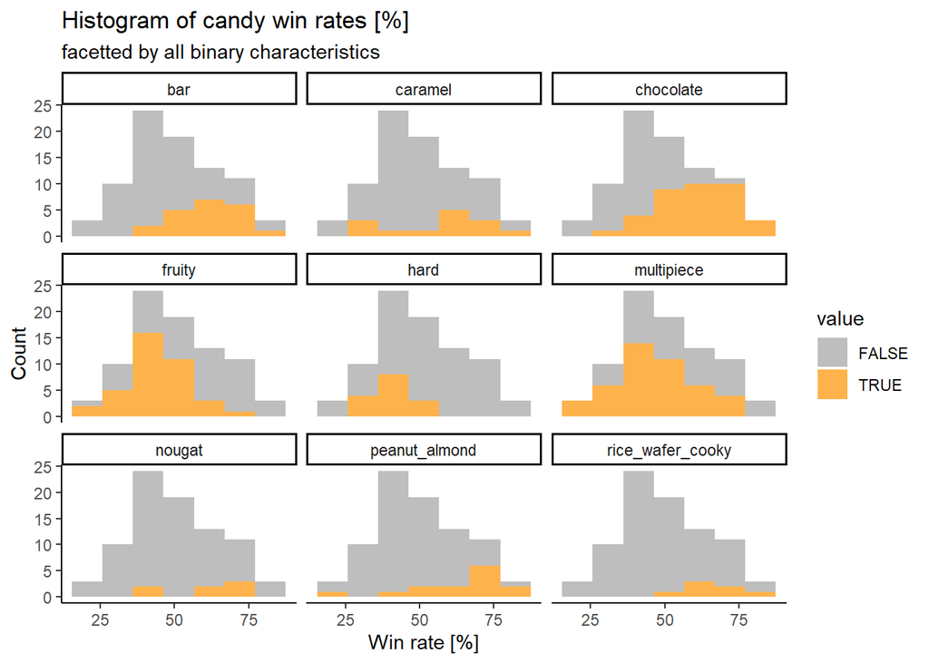

```r
candy_cleaned %>% gather(key = "characteristic", value = "value", chocolate:multipiece) %>%
                  ggplot(aes(winpercent, fill = value)) +
                         geom_histogram(bins = 7) +
                         labs(y = "Count",
                              x = "Win rate [%]",
                              title = "Histogram of candy win rates [%]",
                              subtitle = "facetted by all binary characteristics") +
                         facet_wrap(.~characteristic) +
                         scale_fill_manual(values = c("grey", "#feb24c"))
```

## Numeric candy characteristics

The only remaining numeric candy characteristic ‘sugarpercent’ is visualized below. Here, we see that ‘sugarpercent’ is fairly evenly distributed along all ‘winrates’ (top left) and indicates a poor correlation with respect to ‘winpercent’ (r = 0.21; top right). Nonetheless, as suggested by the loess curve (bottom left), ‘sugarpercent’ may linearly influence ‘winpercent’ rather within a certain (0.0 to 0.5). Therefore, 0.5 ‘sugarpercent’ may mark some sugar threshold value that some of the most favorite candies exceed.

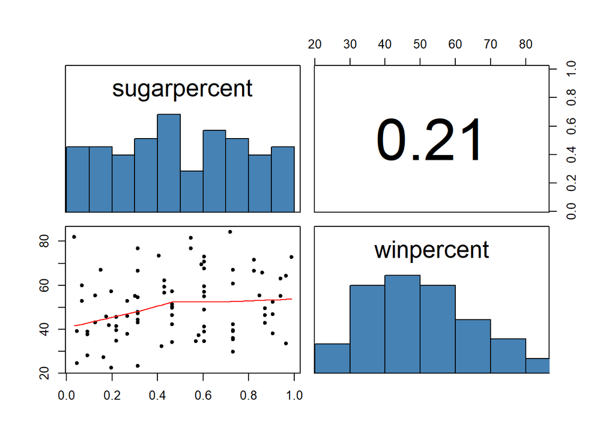

```r
#scatter plot matrix
numeric_variables <- c("sugarpercent", "winpercent")
pairs.panels(candy_cleaned[, numeric_variables], density = F, ellipses = F, rug = F, hist.col = "steelblue")
```

## Multicollinearity among predictor variables?

```r
candy_cleaned_dummy <- candy_cleaned
candy_cleaned_dummy[,c(2:10)] <- lapply(candy_cleaned_dummy[,c(2:10)], as.double)
candy_r <- rcorr(as.matrix(candy_cleaned_dummy[2:11]))
```

# model selection

## Multiple regression

### Raw model (using all characteristics as predictors)

I applied a multiple regression model to evaluate whether candy characteristics can be used to predict the win rates of the online survey (using the cleaned data set). The residuals (or errors) suggest that 50% of the candy ‘winrate’ prediction were off by lower than ~6 %. Maximum errors were on the order of ~20%. Among all predictors, chocolate and fruity seem to have the highest positive impact on win rate (on average, 20 und 11 %, respectively). Even though we already gained some insights about the most influential characteristics, the model´s overall performance is rather poor to moderate since only about half of the win rate´s variability can be explained by the involved candy characteristics (adjusted R² of 0.47).

```r
# multiple regression model (including all predictors)
mr1.lm <-  lm(winpercent ~ ., data = candy_cleaned[-1])
summary(mr1.lm)
```

```
##
## Call:
## lm(formula = winpercent ~ ., data = candy_cleaned[-1])
##
## Residuals:
##      Min       1Q   Median       3Q      Max
## -20.6824  -6.3101   0.3662   6.0192  24.2836
##
## Coefficients:
##                      Estimate Std. Error t value Pr(>|t|)
## (Intercept)           30.7539     4.9806   6.175 3.53e-08 ***
## chocolateTRUE         20.4167     4.0935   4.988 4.09e-06 ***
## fruityTRUE            11.0367     4.0881   2.700  0.00864 **
## caramelTRUE            2.4403     3.6959   0.660  0.51120
## peanut_almondTRUE      9.8877     3.6125   2.737  0.00780 **
## nougatTRUE             1.7957     5.6416   0.318  0.75118
## rice_wafer_cookyTRUE   8.5485     5.2792   1.619  0.10976
## hardTRUE              -5.5352     3.4737  -1.593  0.11544
## barTRUE               -0.4570     4.9042  -0.093  0.92602
## multipieceTRUE        -0.2633     3.1859  -0.083  0.93436
## sugarpercent           8.1247     4.4843   1.812  0.07418 .
## ---
## Signif. codes:  0 '***' 0.001 '**' 0.01 '*' 0.05 '.' 0.1 ' ' 1
##
## Residual standard error: 10.74 on 72 degrees of freedom
## Multiple R-squared:  0.5346, Adjusted R-squared:   0.47
## F-statistic: 8.271 on 10 and 72 DF,  p-value: 9.033e-09
```

### Improving model performance

```r
#expanding code area width
options(width = 200)

#finding combinations of 'fruity' with other attributes
candy_cleaned %>% filter(fruity == TRUE & (chocolate == TRUE |
                                           caramel == TRUE |
                                           peanut_almond == TRUE |
                                           nougat == TRUE |
                                           rice_wafer_cooky == TRUE)) %>%
                  select(c(candy:rice_wafer_cooky, winpercent))
```

```
## # A tibble: 2 × 8
##   candy              chocolate fruity caramel peanut_almond nougat rice_wafer_cooky winpercent
##   <chr>              <lgl>     <lgl>  <lgl>   <lgl>         <lgl>  <lgl>                 <dbl>
## 1 Caramel Apple Pops FALSE     TRUE   TRUE    FALSE         FALSE  FALSE                  34.5
## 2 Tootsie Pop        TRUE      TRUE   FALSE   FALSE         FALSE  FALSE                  49.0
```

# Assumption validation

Filtering the candies accordingly results in only two candies (‘Caramel Apple Pops’ and ‘Tootsie Pop’; see output above) fulfilling these criteria. Both candies have rather low win rates (35 and 49%). Combining ‘fruity’ with other taste-like characteristics seems therefore not only uncommon (probably for a reason) but, if combined anyway, results in rather unsuccessful candies. With respect to our initial goal (finding favorable candy attributes), I suggest to remove both odd candies from the data set. Removing these candies further avoids the observed multicollinearity between ‘chocolate’ and ‘fruity’ and also cleanly splits up the data set in two subgroups (either exclusively fruity or exclusively non-fruity).

```r
#finding indices of odd candies
CAP <- which(candy_cleaned$candy == "Caramel Apple Pops")
TP  <- which(candy_cleaned$candy == "Tootsie Pop")

#removing odd candies
candy_simplified <- candy_cleaned[-c(CAP, TP), ]

#checking frequency of nonfruity and fruity candies
candy_simplified %>% group_by(fruity) %>%
                     count()
```

```
## # A tibble: 2 × 2
## # Groups:   fruity [2]
##   fruity     n
##   <lgl>  <int>
## 1 FALSE     45
## 2 TRUE      36
```

Now, the fruity attribute splits up the data set yielding 45 non-fruity and 36 fruity candies. Based on these distinctively different groups (which mutually exclude each other) I evaluated first which group may be the best candidate for the new candy product. The boxplots below show the distribution of candy win rate for each group suggesting that non-fruity candies should be favored over fruity candies.

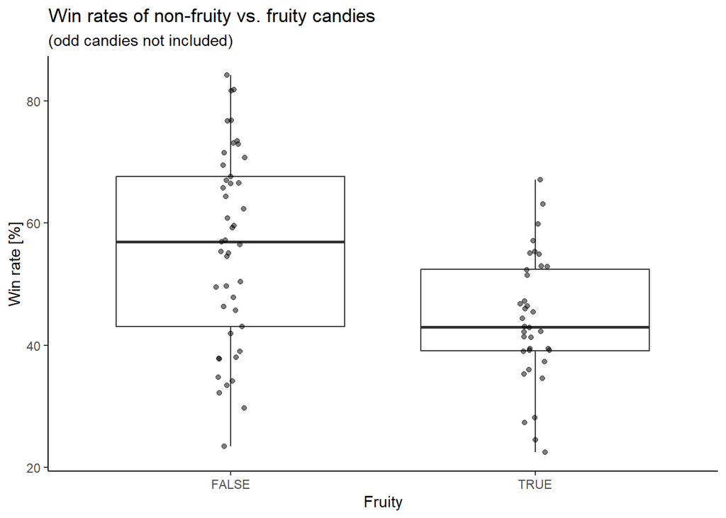

```r
candy_simplified %>% ggplot(aes(fruity, winpercent)) +
                     geom_boxplot() +
                     geom_jitter(width = 0.05, height = 0, alpha= 0.5) +
                     labs(x ="Fruity",
                          y = "Win rate [%]",
                          title = "Win rates of non-fruity vs. fruity candies",
                          subtitle = ("(odd candies not included)"))
```

Applying a t test between group means statistically backs up our findings (see below). Consequently, a non-fruity candy seems to be a reasonable choice when inventing successful new candy product (on average, a 12% higher win rate; p < 0.05)

```r
# statistical verification of differences in 'winpercent' between nonfruity and fruity candies
# F test for equal variances
ftest <- var.test(winpercent ~ fruity, data = candy_simplified)
# t.test between mean 'winrate' of nonfruity and fruity
t.test(winpercent ~ fruity, data = candy_simplified,
                            alternative = "greater",
                            var.equal = (ifelse(ftest$p.value < 0.05, TRUE, FALSE)))
```

```
##
##  Two Sample t-test
##
## data:  winpercent by fruity
## t = 3.8543, df = 79, p-value = 0.0001175
## alternative hypothesis: true difference in means between group FALSE and group TRUE is greater than 0
## 95 percent confidence interval:
##  6.700561      Inf
## sample estimates:
## mean in group FALSE  mean in group TRUE
##            56.04438            44.25138
```

```r
#reducing data set to solely non-fruity candies
candy_nonfruity <- candy_simplified %>% filter(fruity == FALSE) %>% select(-fruity)

# multiple regression model using only nonfruity candy
nonfruity.lm <-  lm(winpercent ~ ., data = candy_nonfruity[ ,-1])
summary(nonfruity.lm)
```

```
##
## Call:
## lm(formula = winpercent ~ ., data = candy_nonfruity[, -1])
##
## Residuals:
##     Min      1Q  Median      3Q     Max
## -18.940  -5.459   2.375   6.007  15.030
##
## Coefficients:
##                      Estimate Std. Error t value Pr(>|t|)
## (Intercept)           33.9652     7.0258   4.834 2.64e-05 ***
## chocolateTRUE         23.9786     4.8400   4.954 1.84e-05 ***
## caramelTRUE            3.1475     4.0863   0.770   0.4463
## peanut_almondTRUE      8.9775     3.7874   2.370   0.0234 *
## nougatTRUE             2.1528     5.8125   0.370   0.7133
## rice_wafer_cookyTRUE   8.4499     5.4154   1.560   0.1277
## hardTRUE               0.6015     9.1229   0.066   0.9478
## barTRUE               -7.3160     6.0913  -1.201   0.2378
## multipieceTRUE        -8.4767     5.4993  -1.541   0.1322
## sugarpercent           8.5009     6.9368   1.225   0.2286
## ---
## Signif. codes:  0 '***' 0.001 '**' 0.01 '*' 0.05 '.' 0.1 ' ' 1
##
## Residual standard error: 10.97 on 35 degrees of freedom
## Multiple R-squared:  0.6174, Adjusted R-squared:  0.519
## F-statistic: 6.274 on 9 and 35 DF,  p-value: 3.053e-05
```

When assessing in detail the influence of the individual characteristics on win rate, we notice that ‘caramel’, ‘nougat’, ‘hard’ barely have any impact (win rate increases by 3, 2 and 1 %, respectively). Moreover, these predictors are highly insignificant (p > 0.44). It seems therefore justified to exclude these predictors in favor of the model´s simplicity.

Furthermore, as noted earlier, ‘sugarpercent’ seems to have a rather non-linear influence on ‘winrate’. Hence, we transform the numeric ‘sugarpercent’ into a logical characteristic (using the threshold value 0.5).

When applying the multiple regression model on the this modified data set (removing ‘caramel’, ‘nougat’, ‘hard’ and transforming ‘sugar’) our model further improves the adjusted R² from 0.52 to 0.57.

```r
#removing highly insignificant predictors and transforming 'sugarpercent' from numeric to binary
candy_nonfruity2 <- candy_nonfruity %>% select(-caramel, -nougat, -hard) %>%
                    mutate(sugar = ifelse(sugarpercent > 0.5, TRUE, FALSE)) %>%
                    select(-sugarpercent)

# multiple regression model using modified data set
nonfruity2.lm <- lm(winpercent ~ ., data = candy_nonfruity2[ ,-1])
summary(nonfruity2.lm)
```

```
##
## Call:
## lm(formula = winpercent ~ ., data = candy_nonfruity2[, -1])
##
## Residuals:
##     Min      1Q  Median      3Q     Max
## -22.111  -5.953   2.712   6.517  15.467
##
## Coefficients:
##                      Estimate Std. Error t value Pr(>|t|)
## (Intercept)            38.184      5.277   7.236 1.18e-08 ***
## chocolateTRUE          22.255      4.189   5.313 4.97e-06 ***
## peanut_almondTRUE       7.799      3.514   2.220   0.0325 *
## rice_wafer_cookyTRUE    7.523      4.643   1.620   0.1135
## barTRUE                -6.661      5.114  -1.302   0.2006
## multipieceTRUE         -9.606      4.992  -1.924   0.0618 .
## sugarTRUE               7.307      3.176   2.301   0.0270 *
## ---
## Signif. codes:  0 '***' 0.001 '**' 0.01 '*' 0.05 '.' 0.1 ' ' 1
##
## Residual standard error: 10.34 on 38 degrees of freedom
## Multiple R-squared:  0.6307, Adjusted R-squared:  0.5724
## F-statistic: 10.82 on 6 and 38 DF,  p-value: 5.331e-07
```

# Results and Conclusion of multiple regression model

The final multiple regression model suggest approximately the following influences on candy win rate. The characteristics are further sorted by their p-value (starting with the lowest; bold ones are < 0.05):

Win rate [%] = 22 x **chocolate** + 7 x **sugar** + 8 x **peanut_almond** - 9 x multipiece + 8 x rice_wafer_cooky - 6 x bar + 38

Interestingly, considering the full data set, no candy fulfills these 6 criteria (see logical expression filtering below). This observation may either point to a candy market niche but may also be misleading. Some of the involved predictors are still rather weakly statistically significant (‘rice_wafer_cooky’, ‘bar’ and ‘multipiece’)). Even though this idea might be worth following, the current data seems insufficient to adequately address this question.

```r
#expanding code area width
options(width = 200)

#finding combinations of 'fruity' with other attributes
candy_cleaned %>% filter(chocolate == TRUE,
                            sugarpercent > 0.5,
                            peanut_almond == TRUE,
                            multipiece == FALSE,
                            rice_wafer_cooky == TRUE,
                            bar == FALSE,
                            ) %>%
                  select(candy)
```

```
## # A tibble: 0 × 1
## # ℹ 1 variable: candy <chr>
```

# Decision tree

```r
# applying decision tree model using the candy_simplified data set
candy_rpart <- rpart(winpercent~., data = candy_cleaned[, -1])

# Checking complexity parameter with lowest cross validation error
printcp(candy_rpart)
```

```
##
## Regression tree:
## rpart(formula = winpercent ~ ., data = candy_cleaned[, -1])
##
## Variables actually used in tree construction:
## [1] caramel       chocolate     fruity        hard          peanut_almond sugarpercent
##
## Root node error: 17837/83 = 214.91
##
## n= 83
##
##         CP nsplit rel error  xerror     xstd
## 1 0.399896      0   1.00000 1.02336 0.130903
## 2 0.057241      1   0.60010 0.65170 0.088110
## 3 0.049449      2   0.54286 0.70402 0.090486
## 4 0.031279      3   0.49341 0.67441 0.088113
## 5 0.028814      4   0.46214 0.66229 0.089266
## 6 0.012604      5   0.43332 0.68410 0.092088
## 7 0.010000      6   0.42072 0.69486 0.095465
```

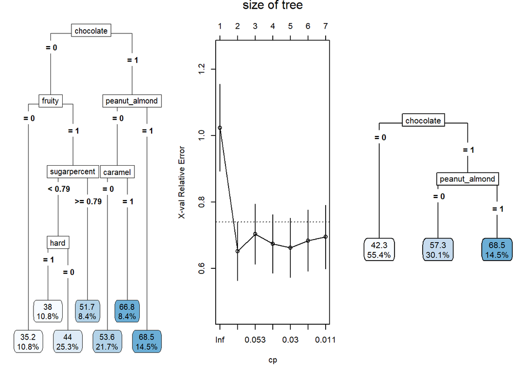

```r
par(mfrow=c(1,3))

#plot raw tree
rpart.plot(candy_rpart, digits = 3, fallen.leaves = T, type = 5, roundint = F)

#visualize cross-validation results
plotcp(candy_rpart)
# pruning of inital tree
pruned_candy_rpart <- prune(candy_rpart, cp = 0.057241)
# plotting pruned tree
rpart.plot(pruned_candy_rpart, digits = 3, fallen.leaves = T, type = 5, roundint = F)
```

The pruning results in a decision tree with only three leaf nodes. Nonetheless, similar as found for our multiple regression model approach, the decision tree defines ‘chocolate’ and ‘peanut_almond’ as most relevant candy characteristics whereby also declaring ‘fruity’ as not relevant.

Below, I listed the candies ending up in the far right leaf node (highest predicted win rate). Even though the listed candies show all a win rate of > 50 % (indicating exclusively candies that are, on average, preferred over others), the overall range of win rates is rather high (about 50 to 84 %). Therefore, the model correctly finds attributes for *favorable* but not necessarily for the *most favorable* candies.

```r
#expanding code area width
options(width = 200)

#finding combinations of 'fruity' with other attributes
candy_cleaned %>% filter(chocolate == TRUE,
                         peanut_almond == TRUE) %>%
                  arrange(desc(winpercent)) %>%
                  select(candy, winpercent)
```

```
## # A tibble: 12 × 2
##    candy                       winpercent
##    <chr>                            <dbl>
##  1 Reese's Peanut Butter cup         84.2
##  2 Reese's Miniatures                81.9
##  3 Snickers                          76.7
##  4 Reese's pieces                    73.4
##  5 Reese's stuffed with pieces       72.9
##  6 Peanut butter M&M's               71.5
##  7 Nestle Butterfinger               70.7
##  8 Peanut M&Ms                       69.5
##  9 Snickers Crisper                  59.5
## 10 Baby Ruth                         56.9
## 11 Mr Good Bar                       54.5
## 12 Almond Joy                        50.3
```

# Model comparison and business recommendation

To further assess both models, I plotted the predicted win rates (using the optimized model ‘nonfruity2.lm’) versus the actual win rates below (left scatter plot). An equivalent plot has been done using the decision tree model (right scatter plot). Overall, the multiple regression model shows a lower MAE compared to the decision tree and is also capable of predicting a much larger range of win rates.

```r
#### Win rate prediction using multiple regression ####
predicted_winpercent_mr <- predict(nonfruity2.lm, candy_nonfruity2)

# Estimating mean absolute error (MAE) as performance metrics
absolut_differences <- abs(candy_nonfruity2$winpercent - predicted_winpercent_mr)
MAE_mr <- sum(absolut_differences) / length(predicted_winpercent_mr)

#### Win rate prediction using decision tree ####
predicted_winpercent_dt <- predict(pruned_candy_rpart, candy_cleaned[, 2:11])

# Estimating mean absolute error (MAE) as performance metrics
absolut_differences_dt <- abs(candy_cleaned$winpercent - predicted_winpercent_dt)
MAE_dt <- sum(absolut_differences_dt) / length(predicted_winpercent_dt)
```

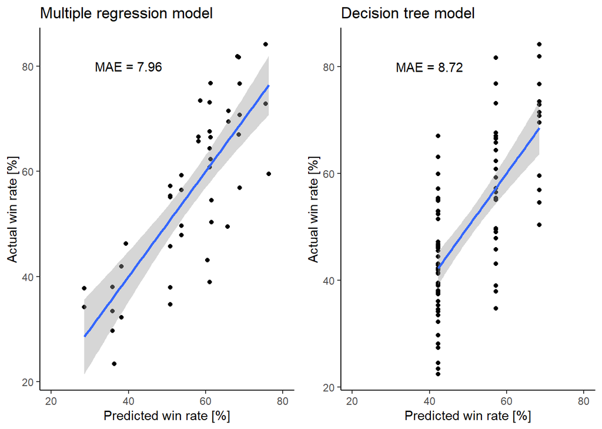

```r
# label creation for plot
labels_mr <- data.frame(x = 40,
                        y = 80,
                        text = paste0("MAE = ", signif(MAE_mr, 3)))

labels_dt <- data.frame(x = 40,
                        y = 80,
                        text = paste0("MAE = ", signif(MAE_dt, 3)))

# Plot of predicted vs. actual winrate (multiple regression)
plot_mr <- candy_nonfruity2 %>% mutate(predicted_winprecent_mr = predicted_winpercent_mr) %>%
                                ggplot(aes(predicted_winpercent_mr, winpercent)) +
                                       geom_point() +
                                       geom_smooth(method = "lm") +
                                       labs(title = "Multiple regression model",
                                            x = "Predicted win rate [%]",
                                            y = "Actual win rate [%]" ) +
                                       xlim(c(20,80)) +
                                       geom_text(data = labels_mr,
                                                 aes(x,y, label = text),
                                                 inherit.aes = F)

# Plot of predicted vs. actual win rate (decision tree)
plot_dt <- candy_cleaned %>%  mutate(predicted_winprecent_dt = predicted_winpercent_dt) %>%
                              ggplot(aes(predicted_winpercent_dt, winpercent)) +
                                geom_point() +
                                geom_smooth(method = "lm") +
                                labs(title = "Decision tree model",
                                     x = "Predicted win rate [%]",
                                     y = "Actual win rate [%]" ) +
                                xlim(c(20,80)) +
                                geom_text(data = labels_dt,
                                          aes(x,y, label = text),
                                          inherit.aes = F)


# preparing a multiple figure plot
grid.arrange(plot_mr, plot_dt, nrow = 1)
```

# Business Recommendation

A business recommendation can be translated from the multiple regression model: a successful candy should be **not fruity** and further have the following characteristics (ordered by importance with key characteristics in bold):

| Characteristics | Consider for new candy product? |
| --- | --- |
| **chocolate** | **definitely** |
| **sugar (>0.5 percentile)** | **yes** |
| **peanuts or almonds** | **yes** |
| multi-piece | optional (rather not) |
| rice/wafer/cooky component | optional (rather yes) |
| bar form | optional (rather not) |

All remaining characteristics (‘nougat’, ‘caramel’, ‘hard’) are not relevant. Following the outlined recommendations should result in a candy that his, on average, mostly preferred over other ones (83 out of 100 times).